# PS data extraction for YFT (2000-2021)

Haikun Xu

2022-06-08

This example code demonstrates how to extract the purse-seine catch and length composition data for the stock assessment of yellowfin tuna in the eastern Pacific Ocean. Data are extracted for yellowfin between 2000 and 2021 based on the R package *BSE* (version 0.1.0). The package can be installed using `devtools::install_github('HaikunXu/BSE',ref='main')`. Fishery definition for this data extraction is based on the benchmark assessment conducted in 2020.

- Step 1: set up some directories and parameters for the extraction

```r
# devtools::install_github('HaikunXu/BSE',ref='main')
library(BSE)

# Load the base files (please ask Haikun to get those data)
raw_data_dir <- "D:/OneDrive - IATTC/IATTC/2022/BSE stuff from Cleridy/spp comp programs_from 2000/Raw data extractions/"
# the directory where output will be saved
save_dir <- "D:/OneDrive - IATTC/IATTC/2022/BSE stuff from Cleridy/YFT/"
yr.start <- 2000
yr.end <- 2021
Species <- "YFT"
grow.increments <- grow.increments.betyftskj # the growth increment matrix
```

- Step 2: lightly process the raw data so that they can be easily used in rest of steps

```r
# Get the total unloads for the PS fleet
total.unlds <- read.unloads.f(raw_data_dir,"Unloading2000-2021.txt",yr.start,yr.end)
# Get the CAE+IDM data
cae <- read.cae.f(raw_data_dir,"CAE-LatLon2000-2021.txt",yr.start,yr.end)
# Get the length-frequency data (length in millimeters)
lfmm <- read.lfmmdata.f(raw_data_dir,"LengthMM2000-2021.txt")
# Get the grouped length-frequency output
lfgrpd <- read.lengthfreq.f(raw_data_dir,"LengthFreq2000-2021.txt")
```

- Step 3: compile the OBJ catch and composition data for YFT

```r
PS <- "OBJ"
area.substitution.mat <- area.substitution.mat.YFT.OBJ.2019ExtRev # for OBJ

cae.stratflg <- create.strat.flg.f(cae$latc5,cae$lonc5,is.lwrght=F,cae$month,cae$setype,cae$class,PS=PS,Species=Species)
lfgrpd.stratflg <- create.strat.flg.f(lfgrpd$lat.5deg,lfgrpd$lon.5deg,is.lwrght=T,floor(lfgrpd$moda/100),lfgrpd$setype,lfgrpd$class,PS=PS,Species=Species)
```

Check the strata definition for OBJ in both cae and lf data sets to make sure that they are correct

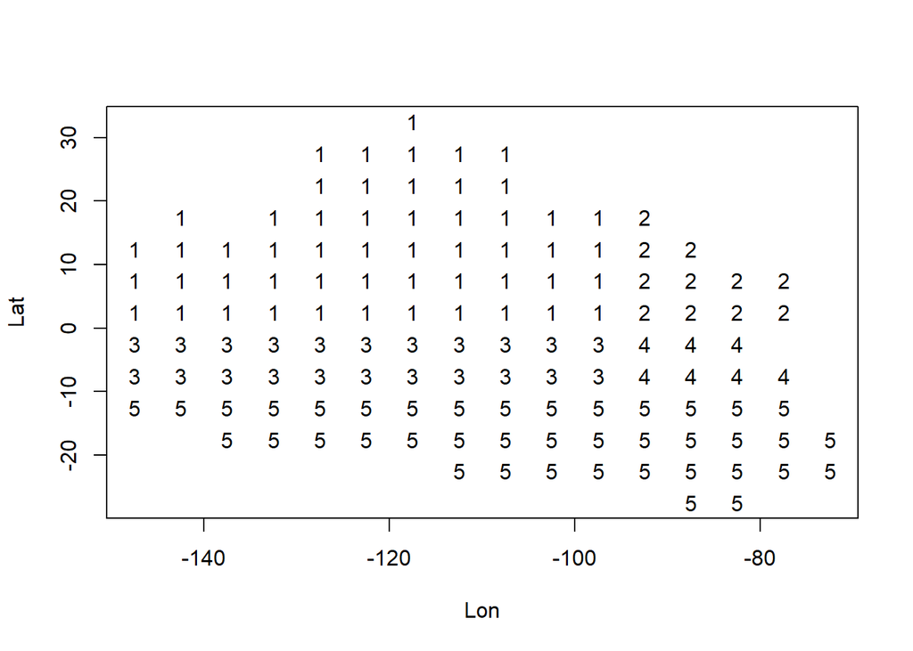

```r
check.strat.flg.f(cae$latc5,cae$lonc5,cae.stratflg)
```

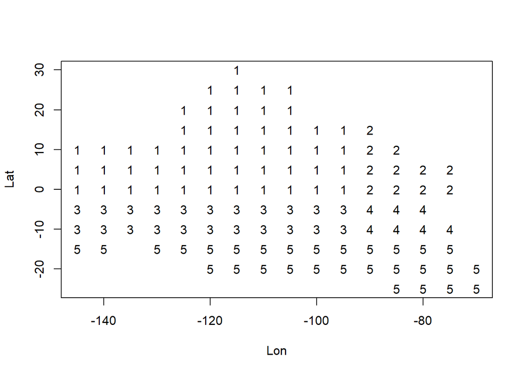

```r
check.strat.flg.f(lfgrpd$lat.5deg,lfgrpd$lon.5deg,lfgrpd.stratflg)
```

Loop through every year between `yr.start` and `yr.end` to get catch and composition data for YFT in the OBJ fishery

```r
for(year in yr.start:yr.end) {
  # print(paste0("Year: ",year))

  # print("Step 1: get well estimates")
  well.estimates <- well.estimates.f(lfgrpd[lfgrpd$year.firstset==year,],lfmm)

  # print("Step 2: get catch estimates")
  catch.estimates <- get.catch.estimates.f(cae,cae.stratflg,total.unlds,lfgrpd,lfgrpd.stratflg,lfmm,year,2,well.estimates,area.substitution.mat,grow.increments,PS=PS,Species=Species)

  # print("Step 3: get fishery estimates")
  fishery.estimates <- fishery.estimates.f(catch.estimates$stratum.estimates.withsamps,catch.estimates$stratum.estimates.NOsamps,year,PS=PS,Species=Species)

  assign(paste0("fishery.estimates.", year), fishery.estimates, pos=1)
}
# save middle-step data as a record
save(list=objects(pat="fishery.estimates"),file=paste0(save_dir,"YFT_",PS,"_2000-2021.RData"))
```

Get final OBJ catch and comp output for the stock assessment

```r
YFT.OBJ.Catch.20002021<-compile.catch.output.f(yr.start,yr.end,PS=PS,Species=Species,c("A1","A2","A3","A4","A5")) # five OBJ fisheries
YFT.OBJ.Comp.20002021<-compile.sizecomps.output.f(yr.start,yr.end,PS=PS,Species=Species)
```

- Step 4: compile the NOA catch and composition data for YFT

```r
PS <- "NOA"
area.substitution.mat <- area.substitution.mat.YFT.UNA.2019ExtRev # for NOA

cae.stratflg <- create.strat.flg.f(cae$latc5,cae$lonc5,is.lwrght=F,cae$month,cae$setype,cae$class,PS=PS,Species=Species)
lfgrpd.stratflg <- create.strat.flg.f(lfgrpd$lat.5deg,lfgrpd$lon.5deg,is.lwrght=T,floor(lfgrpd$moda/100),lfgrpd$setype,lfgrpd$class,PS=PS,Species=Species)
```

Check the strata definition for NOA in both cae and lf data sets to make sure that they are correct

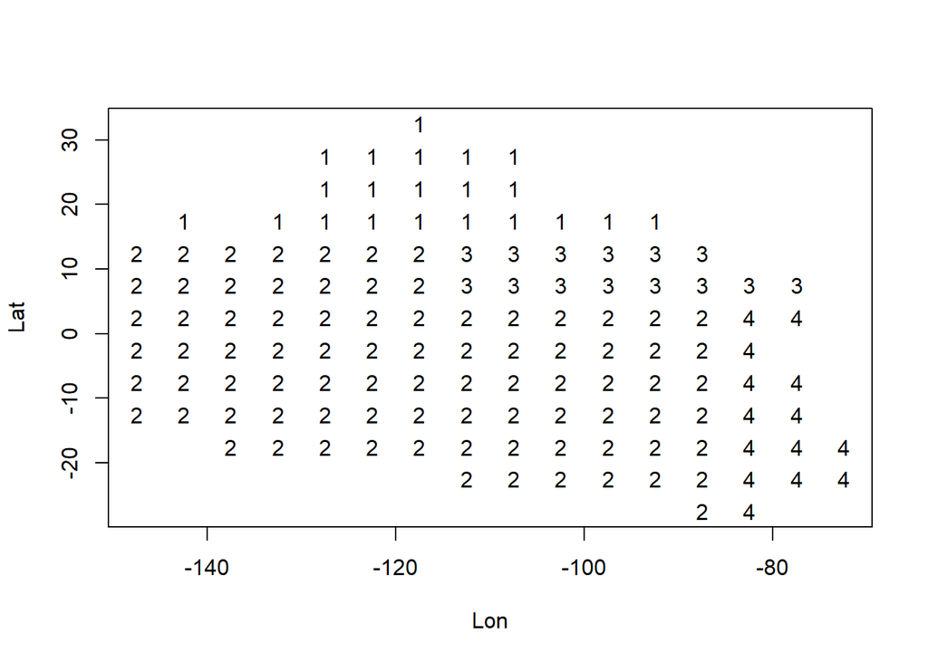

```r
check.strat.flg.f(cae$latc5,cae$lonc5,cae.stratflg)
```